# Hotel_Bookings

Aulia

2022-07-25

In this project I will create visualizations that highlight different aspects of the data using ‘ggplot2’.

#### STEP 1: Load the Data

```r
hotel_bookings <- read.csv("hotel_bookings.csv")
```

#### STEP 2: Load the ‘ggplot2’

```r
library(ggplot2)
```

#### STEP 3: Making a Bar Chart (Part 1)

The stakeholder is interested in developing promotions based on different transactions are occurring for each different distribution type.

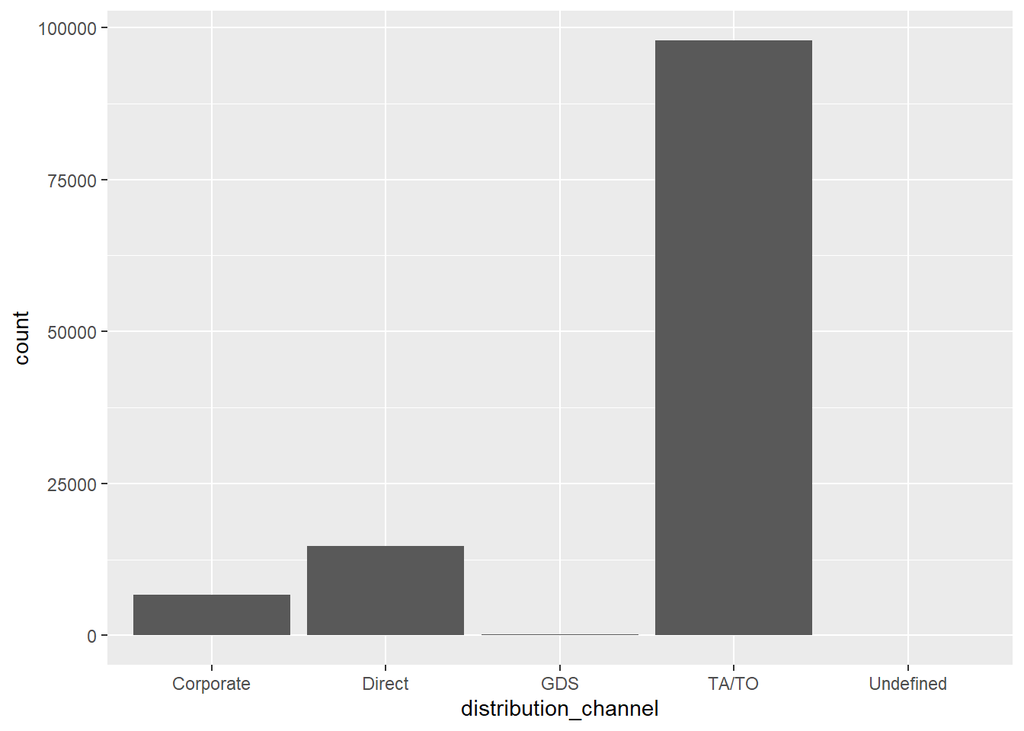

### STEP 4: Making a Bar Chart (Part 2)

they also want to know if the number of bookings for each distribution type is different depending on whether or not there was a deposit or what market segment they represent.

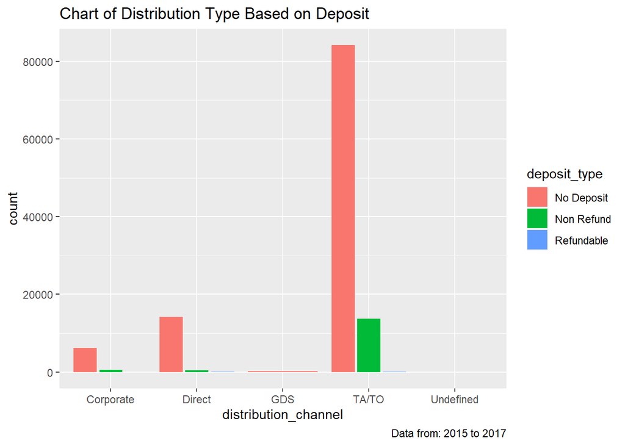

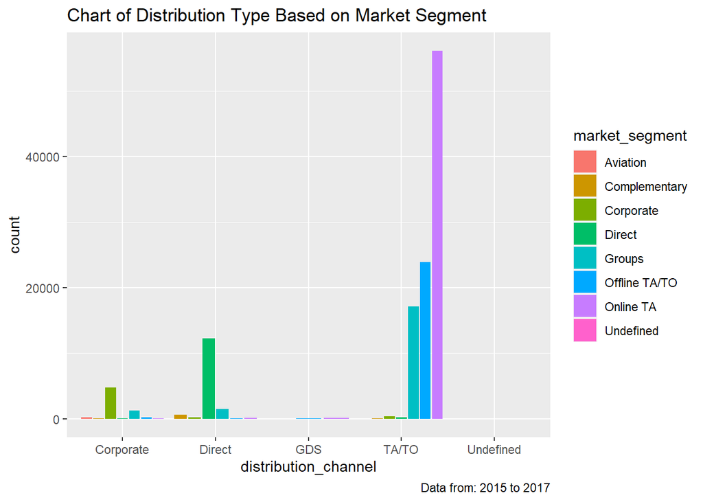

#### Conclusion

From the chart I made the conclusion that TA/TO is more gaining transaction than others distribution type. Based on the second chart it looks like guests is more common with no deposit in the hotel. And based on the last chart, there is a multiple option in every distribution type.

So, I want to give a some kind like solution. If company want to make the decision based on the number, so they better focus on TA/TO. They also have to give more attention on online TA since that market segment is the most popular than others. Company also can give a little gift or discount for groups cause i guess it will give more benefit for company.